# Aula 7: Estruturas de Controle no R

# Estruturas de Controle no R

Nesta aula, vamos explorar as estruturas de controle no R, com foco na utilização do `if-else` e `switch`. Vamos detalhar o uso dessas estruturas e apresentar exemplos contextualizados para ilustrar seu funcionamento.

## Estruturas de Controle

As estruturas de controle permitem fazer execução condicional ou seletiva de instruções conforme o resultado de condições que são testadas. Ou seja, permitem criar desvios e selecionar qual bloco de código será executado.

Os tipos mais comuns são:

- `if-else`: A função mais primitiva para controle de fluxo.
- `switch` (ou `cases`): Uma forma mais enxuta de escrever `if-else` múltiplos.

### If-Else

O `if-else` permite desviar a execução do código conforme uma condição cujo resultado é lógico, ou seja, `TRUE` ou `FALSE`. Se o resultado da condição for `TRUE`, executam-se certas instruções. Se o resultado da condição for `FALSE`, executam-se outras instruções.

#### Estrutura Básica do If-Else

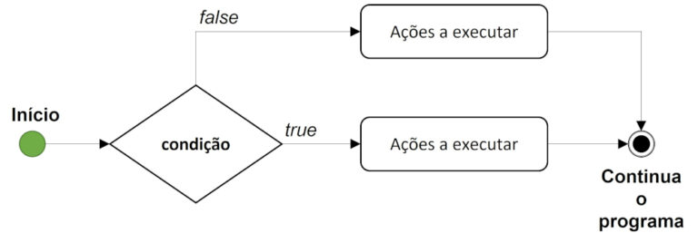

Esqueleto If-Else

A estrutura básica do `if-else` é a seguinte:

```r
if (condição) {
  # Bloco de código a ser executado se a condição for TRUE
} else {
  # Bloco de código a ser executado se a condição for FALSE
}
```

#### Detalhamento dos Parâmetros

- `condição`: Uma expressão lógica que será avaliada como `TRUE` ou `FALSE`.
- Bloco de código: As instruções que serão executadas se a condição for `TRUE` ou `FALSE`.

#### Exemplo Simples de If-Else

Vamos considerar um exemplo onde verificamos se um número é positivo ou negativo.

```r
numero <- 0

if (numero > 0) {
  resultado <- "O número é positivo."
} else {
  resultado <- "O número é negativo."
}

resultado
```

```
[1] "O número é negativo."
```

#### Exemplo Complexo de If-Else com Else-If

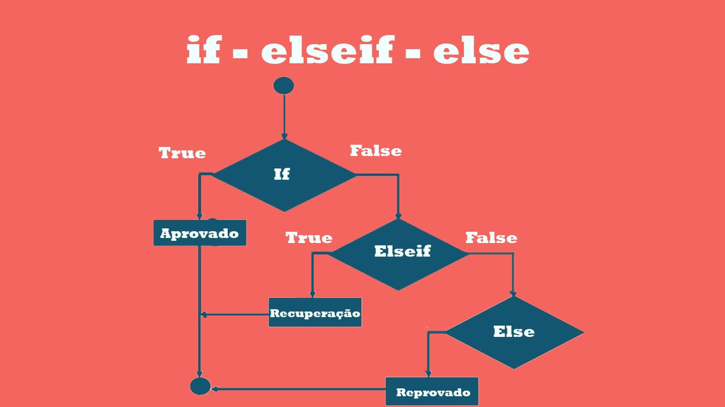

Esqueleto If-elseif-Else

Podemos ter casos mais complexos onde várias condições são testadas utilizando `else if`.

```r
nota <- 55

if (nota >= 90) {
  conceito <- "A"
} else if (nota >= 80) {
  conceito <- "B"
} else if (nota >= 70) {
  conceito <- "C"
} else if (nota >= 60) {
  conceito <- "D"
} else {
  conceito <- "F"
}

conceito
```

```
[1] "F"
```

#### Exemplo com Combinação de Condições

Vamos criar um exemplo que combina duas condições para gerar o resultado.

```r
idade <- 25
renda <- 3000

if (idade >= 18 & renda >= 2500) {
  status <- "Aprovado para o financiamento."
} else if (idade >= 18 & renda < 2500) {
  status <- "Reprovado por renda insuficiente."
} else {
  status <- "Reprovado por idade insuficiente."
}

status
```

```
[1] "Aprovado para o financiamento."
```

#### Exemplo Contextualizado

Suponha que estamos criando um bot para o WhatsApp, e queremos saudar uma pessoa de acordo com a hora do dia.

```r
h <- 13

if (h >= 6 & h < 12) {
  saudacao <- "Bom dia!"
} else if (h >= 12 & h < 18) {
  saudacao <- "Boa tarde!"
} else if (h >= 18 & h < 23) {
  saudacao <- "Boa noite!"
} else {
  saudacao <- "Não estamos atendendo no momento."
  stop("Não estamos atendendo no momento.")
}

saudacao
```

```
[1] "Boa tarde!"
```

#### If-Else com Grupos de Cidades

Vamos utilizar `if-else` para gerar uma mensagem personalizada com base no estado de residência.

Observe que alguns estados do Brasil devemos utilizar a preposição “em”, outros estados devemos utilizar a preposição “na”, e quando for um estado que não esta na lista iremos utilizar a preposição “no”.

```r
grupo_em <- c("Goiás", "Minas Gerais", "Rondônia", "Roraima",
              "Santa Catarina", "São Paulo", "Sergipe")
grupo_na <- c("Bahia", "Paraíba")

estado <- "Minas Gerais" # Teste com diferentes estados como "Rio de Janeiro", "Bahia", "Inglaterra"

if (estado %in% grupo_em) {
  msg <- paste("para você que mora em", estado)
} else if (estado %in% grupo_na) {
  msg <- paste("para você que mora na", estado)
} else {
  msg <- paste("para você que mora no", estado)
}

msg
```

```
[1] "para você que mora em Minas Gerais"
```

### Switch

A estrutura `switch` é uma forma mais enxuta de escrever múltiplos `if-else`. Vamos ver como utilizá-la.

Podemos dizer que a estrutura If-Else é uma estrutura primitiva, agora iremos estudar a estrutura switch que pode ser substituida por estrutura coordenadas de IF-Else.

Inclusive tem muitas linguagens que não tem esse tipo de estrutura presente, no R ela se denomina com Switch no Shell está presente como CASES , o nome geralemnte varia de SWITCH para cases dependendo da linguagem.

Muitas vezes essas estrutura não estarão presentes em outras linguagens, justamente porque podemos reproduzir dua funcionalidade utilizando a estrutura IF- ELSE.

Então o SWITCH basicamente tem a função de empilhar estruturas IF-Else .

Como demonstrado na figura,

[figure not shown]

Esqueleto SWITCH

Onde temos condições empilhadas de if-else , sendo verdadeira algumas delas terao escapes para levar a resposta para um determinado caminho.

O diferencial é que apesar de podermos utilizar uma estrutura similar no IF-ELSE, ele ficara mais complexo para se analisar, entao o SWITCH vem para economizar na escrita de código e entendimento.

#### Estrutura Básica do Switch

A estrutura básica do `switch` é a seguinte:

```r
resultado <- switch(expr,
                    caso1 = valor1,
                    caso2 = valor2,
                    ...,
                    cason = valorn)
```

#### Detalhamento dos Parâmetros

- `expr`: A expressão ou variável que será comparada.
- `caso1`, `caso2`, …, `cason`: Os valores possíveis da expressão.
- `valor1`, `valor2`, …, `valorn`: Os valores retornados se a expressão corresponder ao caso.

#### Exemplo de Uso do Switch

Vamos considerar um exemplo onde selecionamos a cor favorita de uma pessoa.

```r
cor <- "verde"

mensagem <- switch(cor,
                   "vermelho" = "Sua cor favorita é Vermelho!",
                   "azul" = "Sua cor favorita é Azul!",
                   "verde" = "Sua cor favorita é Verde!",
                   "Outra cor")

mensagem
```

[output not shown]

#### Exemplo Contextualizado com Switch

O SWITCH terá um grande aplicabilidade.

Por exemplo podemos utilizar essa função para que o usuário selecione o tipo de métrica que deverá ser aplicada a um vetor de dados.

```r
#tipo_media <- "aritmetica"
#tipo_media <- "harmonica"
tipo_media <- "geometrica"


x <- sample(1:100,50, TRUE)

switch(tipo_media,
       "aritmetica" = {
           mean(x)
       },
       "harmonica" = {
           length(x)/sum(1/x)
       },
       "geometrica" = {
           prod(x)^(1/length(x))
       },
       {
           NA
       })
```

[output not shown]

# Conclusão

Nesta aula, aprendemos a utilizar as estruturas de controle `if-else` e `switch` no R. Vimos exemplos simples e complexos de `if-else`, incluindo a combinação de condições. Também exploramos o uso do `switch` como uma alternativa mais enxuta para múltiplos `if-else`.